# (Dataset Exploration of the FordGo Bike trips in February 2019)

## by (Louaye Lamaa)

> This dataset contains data about the individual trips of the FordGo bike in the San Fransisco area. This notebook explores the main features of the trip such as start and end station, duration, and time as well as the characteristics of the riders such as age, gender and if a user is a customer or subscriber.

```python
# import all packages and set plots to be embedded inline
import numpy as np
import pandas as pd
import matplotlib.pyplot as plt
import seaborn as sb
from datetime import datetime, date

%matplotlib inline
```

> Load in your dataset and describe its properties through the questions below. Try and motivate your exploration goals through this section.

```python
df = pd.read_csv('ford_go_bike.csv')
print(df.shape)
df.head(3)
```

```
(183412, 16)
```

|  | duration_sec | start_time | end_time | start_station_id | start_station_name | start_station_latitude | start_station_longitude | end_station_id | end_station_name | end_station_latitude | end_station_longitude | bike_id | user_type | member_birth_year | member_gender | bike_share_for_all_trip |
| --- | --- | --- | --- | --- | --- | --- | --- | --- | --- | --- | --- | --- | --- | --- | --- | --- |
| 0 | 52185 | 2019-02-28 17:32:10.1450 | 2019-03-01 08:01:55.9750 | 21.0 | Montgomery St BART Station (Market St at 2nd St) | 37.789625 | -122.400811 | 13.0 | Commercial St at Montgomery St | 37.794231 | -122.402923 | 4902 | Customer | 1984.0 | Male | No |
| 1 | 42521 | 2019-02-28 18:53:21.7890 | 2019-03-01 06:42:03.0560 | 23.0 | The Embarcadero at Steuart St | 37.791464 | -122.391034 | 81.0 | Berry St at 4th St | 37.775880 | -122.393170 | 2535 | Customer | NaN | NaN | No |
| 2 | 61854 | 2019-02-28 12:13:13.2180 | 2019-03-01 05:24:08.1460 | 86.0 | Market St at Dolores St | 37.769305 | -122.426826 | 3.0 | Powell St BART Station (Market St at 4th St) | 37.786375 | -122.404904 | 5905 | Customer | 1972.0 | Male | No |

## Preliminary Wrangling

### Assessing

```python
df.info()
```

```
<class 'pandas.core.frame.DataFrame'>
RangeIndex: 183412 entries, 0 to 183411
Data columns (total 16 columns):
 #   Column                   Non-Null Count   Dtype
---  ------                   --------------   -----
 0   duration_sec             183412 non-null  int64
 1   start_time               183412 non-null  object
 2   end_time                 183412 non-null  object
 3   start_station_id         183215 non-null  float64
 4   start_station_name       183215 non-null  object
 5   start_station_latitude   183412 non-null  float64
 6   start_station_longitude  183412 non-null  float64
 7   end_station_id           183215 non-null  float64
 8   end_station_name         183215 non-null  object
 9   end_station_latitude     183412 non-null  float64
 10  end_station_longitude    183412 non-null  float64
 11  bike_id                  183412 non-null  int64
 12  user_type                183412 non-null  object
 13  member_birth_year        175147 non-null  float64
 14  member_gender            175147 non-null  object
 15  bike_share_for_all_trip  183412 non-null  object
dtypes: float64(7), int64(2), object(7)
memory usage: 22.4+ MB
```

```python
df.duplicated().sum()
```

```
0
```

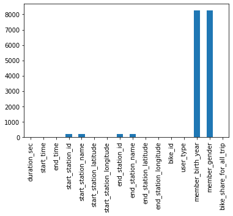

```python
df.isnull().sum().plot.bar()
# not alot of the missing values, I will the rows containing these values
```

```python
df[df.start_station_id.isnull()]
```

|  | duration_sec | start_time | end_time | start_station_id | start_station_name | start_station_latitude | start_station_longitude | end_station_id | end_station_name | end_station_latitude | end_station_longitude | bike_id | user_type | member_birth_year | member_gender | bike_share_for_all_trip |
| --- | --- | --- | --- | --- | --- | --- | --- | --- | --- | --- | --- | --- | --- | --- | --- | --- |
| 475 | 1709 | 2019-02-28 20:55:53.9320 | 2019-02-28 21:24:23.7380 | NaN | NaN | 37.40 | -121.94 | NaN | NaN | 37.40 | -121.93 | 4211 | Customer | 1991.0 | Female | No |
| 1733 | 1272 | 2019-02-28 18:32:34.2730 | 2019-02-28 18:53:46.7270 | NaN | NaN | 37.40 | -121.94 | NaN | NaN | 37.41 | -121.96 | 4174 | Subscriber | 1980.0 | Male | No |
| 3625 | 142 | 2019-02-28 17:10:46.5290 | 2019-02-28 17:13:09.4310 | NaN | NaN | 37.41 | -121.95 | NaN | NaN | 37.41 | -121.96 | 4283 | Subscriber | 1988.0 | Male | No |
| 4070 | 585 | 2019-02-28 16:28:45.9340 | 2019-02-28 16:38:31.3320 | NaN | NaN | 37.39 | -121.93 | NaN | NaN | 37.40 | -121.92 | 4089 | Subscriber | 1984.0 | Male | Yes |
| 5654 | 509 | 2019-02-28 12:30:17.1310 | 2019-02-28 12:38:46.3290 | NaN | NaN | 37.40 | -121.92 | NaN | NaN | 37.39 | -121.93 | 4089 | Subscriber | 1984.0 | Male | Yes |
| ... | ... | ... | ... | ... | ... | ... | ... | ... | ... | ... | ... | ... | ... | ... | ... | ... |
| 176154 | 1447 | 2019-02-02 12:03:04.5440 | 2019-02-02 12:27:12.2670 | NaN | NaN | 37.40 | -121.93 | NaN | NaN | 37.40 | -121.93 | 4249 | Customer | 1984.0 | Male | No |
| 179730 | 309 | 2019-02-01 12:59:45.9690 | 2019-02-01 13:04:55.4260 | NaN | NaN | 37.40 | -121.94 | NaN | NaN | 37.40 | -121.93 | 4249 | Customer | 1987.0 | Female | No |
| 179970 | 659 | 2019-02-01 12:17:37.6750 | 2019-02-01 12:28:37.0140 | NaN | NaN | 37.41 | -121.96 | NaN | NaN | 37.41 | -121.94 | 4092 | Subscriber | 1999.0 | Female | No |
| 180106 | 2013 | 2019-02-01 11:33:55.1470 | 2019-02-01 12:07:28.9400 | NaN | NaN | 37.40 | -121.94 | NaN | NaN | 37.40 | -121.94 | 4251 | Customer | 1990.0 | Female | No |
| 181201 | 312 | 2019-02-01 09:26:34.8030 | 2019-02-01 09:31:46.9210 | NaN | NaN | 37.40 | -121.93 | NaN | NaN | 37.40 | -121.93 | 4208 | Subscriber | 1987.0 | Male | No |

197 rows × 16 columns

### What is the structure of your dataset?

> This dataset contains data about 183412 trips with 14 variables (duration of the trip, start and end time /start and end station id, name and coordinates/gender, year of birth and type of the users/ service bike share for all). The most variables - after cleaning- are categorical. The numeric variables are duration, age, and coordinates.

### What is/are the main feature(s) of interest in your dataset?

> I am intrested to see how the duration and time of the trips vary based on the characterstics of the users in term of age, gender, customer or subscriber.
> - What time the bikes are most used (day of week, day of the month, hour of the day)?
> - The duration of the trips ?
> - What are the characteristics of the users in term of age, gender and type and how these feature are related to the duration and time of the trips ?

### What features in the dataset do you think will help support your investigation into your feature(s) of interest?

> I think the gender, age and user type will have an impact on the duration of the trips. Also, I expect user type will have an effect on the time the trips are taken. In addition, the time of the trip could have an effect on its duration. I expect that the start and end station might have an slight effect on the duration.

### Tidiness:

- start and end time have three variables : date of month, day of week , hour of the day.
- create a new column for age from the birth date column.

### Quality:

1) duration is better to be in minutes for clearer analysis 2) Errorneous datatypes:

- duration (in minutes) to datetime
- start_station_id and end_station_id and bike_id to string
- user_type, member_gender, day of week and hour of day to category

## cleaning

```python
df_clean = df.copy()
# create a duration columns in minutes
df_clean['duration_mins'] = df_clean['duration_sec'] / 60
df_clean['duration_mins'] = round(df_clean['duration_mins'],2)
df_clean['duration_mins'].head()
```

```
0     869.75
1     708.68
2    1030.90
3     608.17
4      26.42
Name: duration_mins, dtype: float64
```

```python
#start and end time to datetime
df_clean[['start_time','end_time']] = df_clean[['start_time','end_time']].apply(pd.to_datetime)
#stations data to string
df_clean[['start_station_id','end_station_id']] = df_clean[['start_station_id','end_station_id']].astype(str)
# gender to category
df_clean['member_gender'] = df_clean['member_gender'].astype('category')
df_clean['user_type'] = df_clean['user_type'].astype('category')
```

```python
df_clean.dtypes
```

```
duration_sec                        int64
start_time                 datetime64[ns]
end_time                   datetime64[ns]
start_station_id                   object
start_station_name                 object
start_station_latitude            float64
start_station_longitude           float64
end_station_id                     object
end_station_name                   object
end_station_latitude              float64
end_station_longitude             float64
bike_id                             int64
user_type                        category
member_birth_year                 float64
member_gender                    category
bike_share_for_all_trip            object
duration_mins                     float64
dtype: object
```

```python
#exctract the week of the month, day of the week and hour of day, and if day is weekend/weekday
df_clean['day_date'] = df_clean['start_time'].dt.day
df_clean['day_name'] = df_clean['start_time'].dt.day_name()
df_clean['hour'] = df_clean['start_time'].dt.hour
```

```python
df_clean['hour'] = df_clean['hour'].astype('category')
days_of_month = ['Monday','Tuesday','Wednesday','Thursday','Friday','Saturday','Sunday']
day_class = pd.api.types.CategoricalDtype(ordered=True,categories=days_of_month)
df_clean['day_name'] = df_clean['day_name'].astype(day_class)
```

```python
df_clean.day_name.value_counts()
```

```
Thursday     35197
Tuesday      31813
Wednesday    29641
Friday       28981
Monday       26852
Sunday       15523
Saturday     15405
Name: day_name, dtype: int64
```

```python
df_clean['week_day_end'] = df_clean['day_name'].apply(lambda x: 'Weekend' if x == 'Sunday' or x == 'Saturday' else 'Weekday')
```

```python
#create a new column for age from the year of birth
df_clean['time'] = df_clean['start_time'].dt.time
df_clean['date'] = df_clean['start_time'].dt.date

df_clean['date'] = pd.to_datetime(df_clean['date'])
df_clean['age'] = df_clean.date.dt.year - df_clean.member_birth_year
```

Now I will check if there any other quality issues in the dataset

```python
df_clean.columns
```

```
Index(['duration_sec', 'start_time', 'end_time', 'start_station_id',
       'start_station_name', 'start_station_latitude',
       'start_station_longitude', 'end_station_id', 'end_station_name',
       'end_station_latitude', 'end_station_longitude', 'bike_id', 'user_type',
       'member_birth_year', 'member_gender', 'bike_share_for_all_trip',
       'duration_mins', 'day_date', 'day_name', 'hour', 'week_day_end', 'time',
       'date', 'age'],
      dtype='object')
```

```python
df_clean.sample(5)
```

|  | duration_sec | start_time | end_time | start_station_id | start_station_name | start_station_latitude | start_station_longitude | end_station_id | end_station_name | end_station_latitude | ... | member_gender | bike_share_for_all_trip | duration_mins | day_date | day_name | hour | week_day_end | time | date | age |
| --- | --- | --- | --- | --- | --- | --- | --- | --- | --- | --- | --- | --- | --- | --- | --- | --- | --- | --- | --- | --- | --- |
| 124931 | 382 | 2019-02-11 08:09:43.006 | 2019-02-11 08:16:05.592 | 200.0 | 2nd Ave at E 18th St | 37.800214 | -122.253810 | 163.0 | Lake Merritt BART Station | 37.797320 | ... | Other | No | 6.37 | 11 | Monday | 8 | Weekday | 08:09:43.006000 | 2019-02-11 | 35.0 |
| 65659 | 798 | 2019-02-20 09:16:53.439 | 2019-02-20 09:30:11.489 | 112.0 | Harrison St at 17th St | 37.763847 | -122.413004 | 363.0 | Salesforce Transit Center (Natoma St at 2nd St) | 37.787492 | ... | Male | No | 13.30 | 20 | Wednesday | 9 | Weekday | 09:16:53.439000 | 2019-02-20 | 37.0 |
| 78036 | 357 | 2019-02-18 21:21:35.741 | 2019-02-18 21:27:32.899 | 61.0 | Howard St at 8th St | 37.776513 | -122.411306 | 100.0 | Bryant St at 15th St | 37.767100 | ... | Male | No | 5.95 | 18 | Monday | 21 | Weekday | 21:21:35.741000 | 2019-02-18 | 26.0 |
| 51776 | 433 | 2019-02-21 17:46:50.821 | 2019-02-21 17:54:04.654 | 171.0 | Rockridge BART Station | 37.844279 | -122.251900 | 210.0 | 45th St at Manila | 37.833294 | ... | Female | No | 7.22 | 21 | Thursday | 17 | Weekday | 17:46:50.821000 | 2019-02-21 | 58.0 |
| 151231 | 266 | 2019-02-06 17:30:14.571 | 2019-02-06 17:34:41.463 | 7.0 | Frank H Ogawa Plaza | 37.804562 | -122.271738 | 337.0 | Webster St at 19th St | 37.806970 | ... | Male | No | 4.43 | 6 | Wednesday | 17 | Weekday | 17:30:14.571000 | 2019-02-06 | 25.0 |

5 rows × 24 columns

```python
df_clean.info()
```

```
<class 'pandas.core.frame.DataFrame'>
RangeIndex: 183412 entries, 0 to 183411
Data columns (total 24 columns):
 #   Column                   Non-Null Count   Dtype
---  ------                   --------------   -----
 0   duration_sec             183412 non-null  int64
 1   start_time               183412 non-null  datetime64[ns]
 2   end_time                 183412 non-null  datetime64[ns]
 3   start_station_id         183412 non-null  object
 4   start_station_name       183215 non-null  object
 5   start_station_latitude   183412 non-null  float64
 6   start_station_longitude  183412 non-null  float64
 7   end_station_id           183412 non-null  object
 8   end_station_name         183215 non-null  object
 9   end_station_latitude     183412 non-null  float64
```

[output cut: 16 more lines]

## Univariate Exploration

### Distribution of the trips time in term of the day of month, day of week and hour of the day

I will check the distribution of the trips over the days of the month of february (1-28), days of the week, and hours of the days. If we want to work on a full year, we can see the trips over each month.

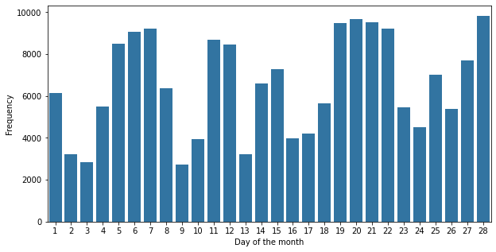

```python
base_color = sb.color_palette()[0]
#distribution over the days of the month
plt.figure(figsize=[10,5])
sb.countplot(data=df_clean,x='day_date',color=base_color)
plt.xlabel('Day of the month')
plt.ylabel('Frequency')
```

From the bar chart above, it looks like there are four periods of high usage activity of bikes, from day 5 to 7, day 11 and day 12,from day 19 to 22, and the last day of the month. The days with lower trips could be related if it is a weekend or a weekday. The day of the month doesn't seem to have any interesting observation, so I don't think It will be used in the next sections of the analysis.

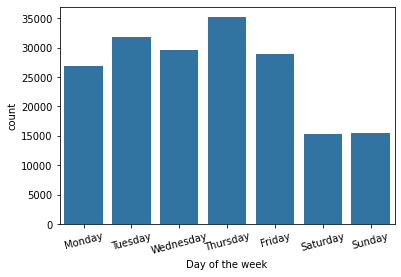

```python
#distribution of the trips over the days of the week
sb.countplot(data=df_clean,x='day_name',color=base_color)
plt.xlabel('Day of the week')
plt.xticks(rotation=15);
```

We can see that thursday has the most trips, followed by tuesday and wednesday. There i a big drop in the number of trips in the days of the weekend. That will be intresting to analyze with other features such as user type to find the reason. Below, a bar chart shows the big difference between the number of trips on the weekdays and weekend.

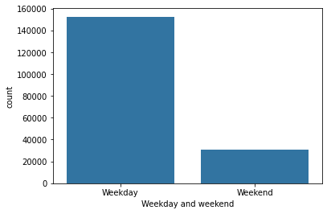

```python
sb.countplot(data=df_clean,x='week_day_end',color=base_color)
plt.xlabel('Weekday and weekend');
```

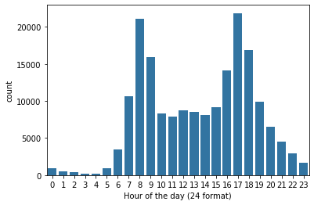

```python
# distribtion over the hours of the day
sb.countplot(data=df_clean,x='hour',color=base_color);
plt.xlabel('Hour of the day (24 format)')
```

The distribution of the hours of the day is bimodal, with two peaks at 8 am (and a smaller one at 9 am) and at 5 pm (and a smaller one at 5 pm)), which could be related to the start and end of the work day. The trips between these two hours decrease as we approach the noon, and become much fewer between the late hours of the night and the early hours of the morning. The difference of distribtion over the day could be an indication of the purpose of the trips and the relation with the type of the users, so further investigation will address this in the next section.

### Distribution of trips duration in minutes

```
(0.0, 200.0)
```

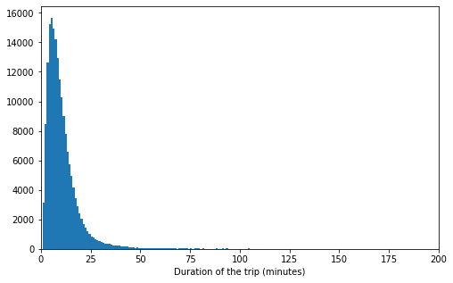

```python
bins= np.arange(df_clean.duration_mins.min(),df_clean.duration_mins.max()+1,1)
#distribution of the duration of the trip
plt.figure(figsize=[8, 5])
plt.hist(data=df_clean,x='duration_mins',bins=bins);
plt.xlabel('Duration of the trip (minutes)')
# define an axis limit because it is very skewed
plt.xlim(0,200)
```

```python
df_clean.duration_mins.describe()
```

```
count    183412.000000
mean         12.101301
std          29.906501
min           1.020000
25%           5.420000
50%           8.570000
75%          13.270000
max        1424.070000
Name: duration_mins, dtype: float64
```

The distribution above is highly right skewed, with most durations are under 30 minutes and few trips with a really high duration. So, I will use a log scale instead.

```python
np.log10(df_clean.duration_mins.describe())
```

```
count    5.263428
mean     1.082832
std      1.475766
min      0.008600
25%      0.733999
50%      0.932981
75%      1.122871
max      3.153531
Name: duration_mins, dtype: float64
```

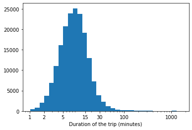

```python
# log scale distributon
log_bins = 10 ** np.arange(np.log10(df_clean.duration_mins.min()),np.log10(df_clean.duration_mins.max())+0.1,0.1)
plt.hist(data=df_clean,x='duration_mins',bins=log_bins)
plt.xscale('log')
plt.xticks([1,2,5,15,30,100,1000],[1,2,5,15,30,100,1000]);
plt.xlabel('Duration of the trip (minutes)');
```

On the log scalled plot, we can see a unimodal normal distibution with a peak at around 10 minutes. Most durations fall between 5 and 15 minutes. There is very high values that could be outliers, should be handled to give us a better analysis since the 3rd percentile is 13 while we have some values bigger than 500. I will use clipping method to handle these values. There is different features that could affect the duration such as user type or age. I will analyze the relationship between duration and other factors in the next part.

```python
#disribution have outliers from the high ==> clipping
# upper limit - .99 quantile ==> clipped by 99 percent quantile (all points falls outside this range will reduced the upper value of the range)
upper_limit = df_clean['duration_mins'].quantile(0.99) + 30
# lower limit - .05 quantile
lower_limit = df_clean['duration_mins'].quantile(0.0)
df_clean['duration_quantile'] = df_clean['duration_mins'].clip(lower_limit, upper_limit, axis = 0)
```

```python
df_clean.duration_quantile.describe()
```

```
count    183412.000000
mean         11.058186
std          10.154541
min           1.020000
25%           5.420000
50%           8.570000
75%          13.270000
max          87.647800
Name: duration_quantile, dtype: float64
```

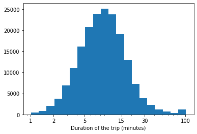

```python
#replot with the removed outliers
bins= 10 ** np.arange(np.log10(df_clean.duration_quantile.min()),np.log10(df_clean.duration_quantile.max())+0.1,0.1)
plt.hist(data=df_clean,x='duration_quantile',bins=bins);
plt.xlabel('Duration of the trip (minutes)')
plt.xscale('log')
plt.xticks([1,2,5,15,30,100],[1,2,5,15,30,100]);
plt.xlabel('Duration of the trip (minutes)')
```

```python
# easier when working with multivariate analysis
def log_trans(x,inverse=False):
    """ Transform a column to log scale """
    if not inverse:
        return np.log10(x)
    else:
        return np.power(10,x)
df_clean['log_duration_quantile'] = df_clean['duration_quantile'].apply(log_trans)
```

### Distribution of the gender

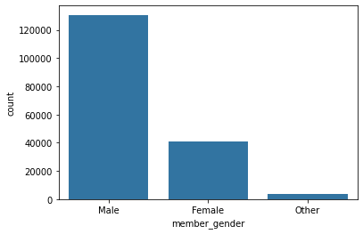

```python
# distribution of the gender
base_color = sb.color_palette()[0]
sb.countplot(data=df_clean,x='member_gender',color=base_color,order=df_clean.member_gender.value_counts().index)
```

The majority of the users are male (more than three times the number of females), while there is a few users with gender called as other.

### distribution of age

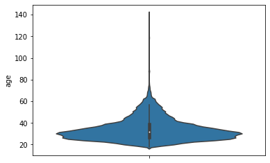

```python
sb.violinplot(data=df_clean,y='age')
```

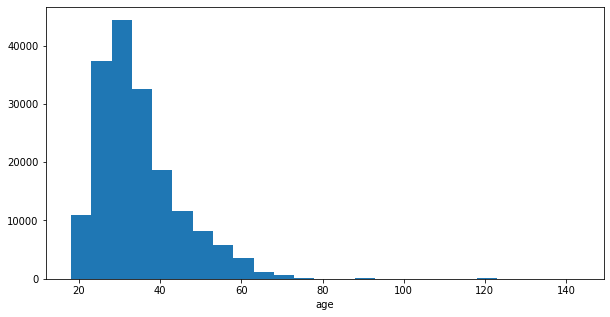

```python
#distribution of age
plt.figure(figsize=[10,5])
bins = np.arange(df_clean.age.min(),df_clean.age.max()+5,5)
plt.hist(data=df_clean,x='age',bins=bins);
plt.xlabel('age');
```

The age of the users is mainly between 25 and 40, but we can see there is some older users that looks like outliers, so we have to remove them. I will remove the users with age above 75 (Although the outliers are defined using IQR*1.5, I think keeping age under 75 is better than remove all obervations above 60 years old). Next, I will try to find how age affect other features such as duration.

```python
df_clean = df_clean.query('age <= 75' )
df_clean.shape
```

```
(174884, 26)
```

### Distribution of user type

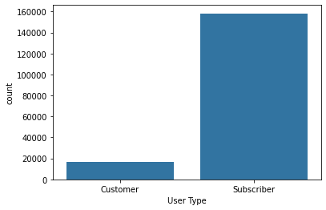

```python
#type of the user
sb.countplot(data=df_clean,x='user_type',color=base_color)
plt.xlabel('User Type');
```

As expected, the subscribers used the services way more than the casual people. My goal is to see how these two groups of users differ such as age, gender, and duration.

### Distribution of bike share for all service

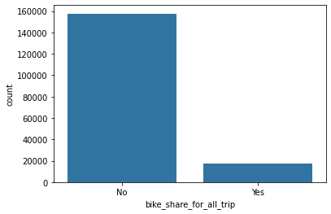

```python
sb.countplot(data=df_clean,x='bike_share_for_all_trip',color=base_color)
```

Most of the subscribers don't use this service (it is just for the subscribers), so it is a good idea to see here what are the differences between the subscribers using this service and between who don't.

### Distribution of start stations

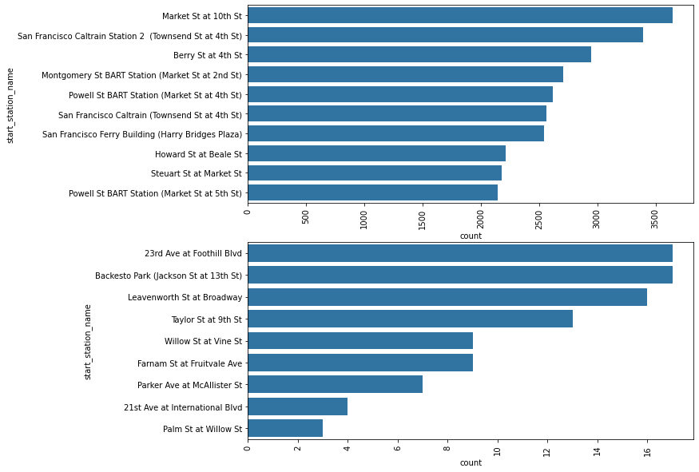

```python
#as there alot of station, and the plot will not be clear, I will plot just the most and less 10 start station, same with end station
plt.figure(figsize=[10,10])
plt.subplot(2,1,1)
sb.countplot(data=df_clean,y='start_station_name',color=base_color,order=df_clean.start_station_name.value_counts().iloc[:10].index)
plt.xticks(rotation=90);
plt.subplot(2,1,2)
sb.countplot(data=df_clean,y='start_station_name',color=base_color,order=df_clean.start_station_name.value_counts().iloc[-10:-1].index)
plt.xticks(rotation=90);
```

### Discuss the distribution(s) of your variable(s) of interest. Were there any unusual points? Did you need to perform any transformations?

> The trips are more common in the weekdays than in the weekends. The hour of day distrbution shows two peaks at the start and end of the work day, at 8-9 am and 5-6 pm. The majority of the riders are male, and the most of the users are subscribers and don't use the bike all share service. The age of the most riders is between 25 and 40 with some older users above 75 years old. The duration of trips took on a large range of high values, so I applied a log transfomation to look at the data. The log distrbution shows that the most of the trips lasts between 5 and 15 minutes.

### Of the features you investigated, were there any unusual distributions? Did you perform any operations on the data to tidy, adjust, or change the form of the data? If so, why did you do this?

> The age of the users has some unsual distribution with very old bikers, so I decided to remove the obervations with age higher than 75. To make the data easier to analyze, I created columns for the hours of the day, and type of the day (weekend and weekday) from the start time column. Also, I calculated the age of the riders from the year of birth as it is easier to understand, and I transformed the seconds into minutes as it is clearer to interpret.

## Bivariate Exploration

### Relationship between trips duration and the days of week

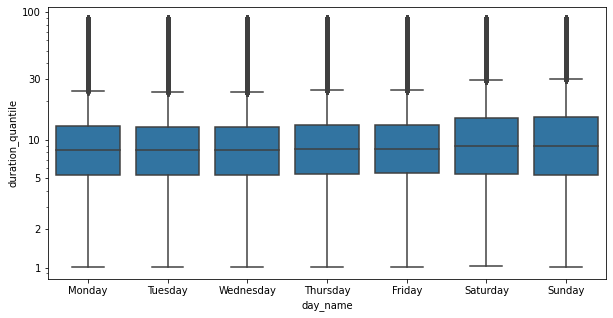

```python
# I will use the clipped duration ( the 99 quantile) and I will work with the log scale
plt.figure(figsize=[10,5])
sb.boxplot(data=df_clean,x='day_name',y='duration_quantile',color=base_color)
plt.yscale('log')
plt.yticks([1,2,5,10,30,100],[1,2,5,10,30,100]);
```

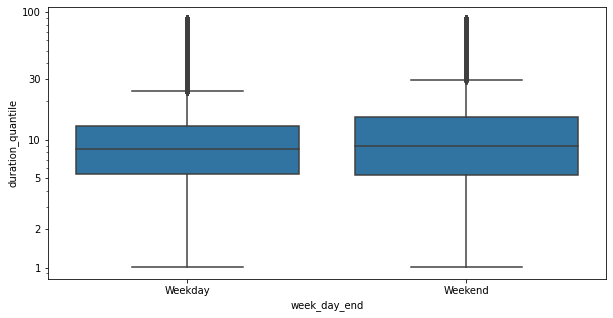

```python
plt.figure(figsize=[10,5])
sb.boxplot(data=df_clean,x='week_day_end',y='duration_quantile',color=base_color)
plt.yscale('log')
plt.yticks([1,2,5,10,30,100],[1,2,5,10,30,100]);
```

The median of the trips duration, as well as IQR and range, on the weekend are higher than these on the weekdays. It seems there is no trend between the duration and the different weekdays. This could be related to the main purpose as usage for work. More analysis with other variables such as the characterstics of the users will lead to a clearer image.

### Relationhip between duration and age

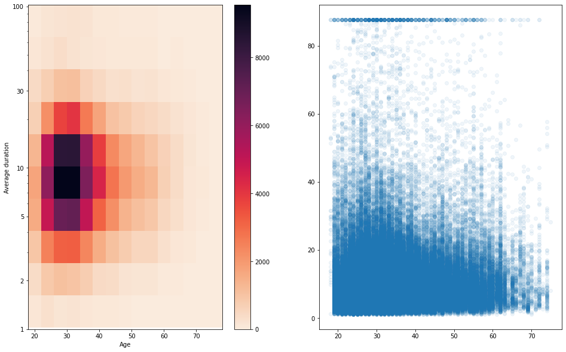

```python
bin_x = np.arange(df_clean.age.min(),df_clean.age.max()+4,4)
bin_y = 10 ** np.arange(np.log10(df_clean.duration_quantile.min()),np.log10(df_clean.duration_quantile.max())+0.2,0.2)
plt.figure(figsize=[16,10])
plt.subplot(1,2,1)
plt.hist2d(data=df_clean,x='age',y='duration_quantile',bins = [bin_x,bin_y],cmap='rocket_r');
plt.yscale('log')
plt.yticks([1,2,5,10,30,100],[1,2,5,10,30,100]);
plt.colorbar()
plt.xlabel('Age')
plt.ylabel('Average duration')
plt.subplot(1,2,2)
plt.scatter(data=df_clean,x='age',y='duration_quantile',alpha=1/15);
```

From the heatmap and the scatter plot above, we can see that the most users are between 25 and 40. The younger bikers tend to ride for higher duration (more trips with 20 minutes and above) than the average (10.8), while the mojaority of older users tend to have trips that around or less than 10 minutes. So, we can see that the duration of the trips depend on the age of the users.

### Relationship between duration and gender

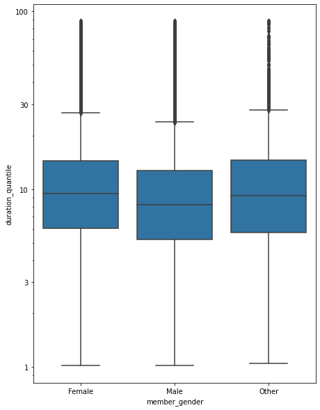

```python
plt.figure(figsize=[16,10])
plt.subplot(1,2,1)
sb.boxplot(data=df_clean,x='member_gender',y='duration_quantile',color=base_color)
plt.yscale('log')
plt.yticks([1,3,10,30,100],[1,3,10,30,100]);
```

### Relationship between duration and user type

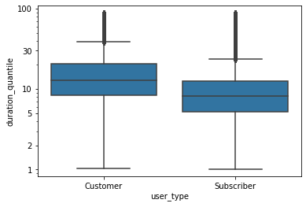

```python
sb.boxplot(data=df_clean,x='user_type',y='duration_quantile',color=base_color)
plt.yscale('log')
plt.yticks([1,2,5,10,30,100],[1,2,5,10,30,100]);
```

Interestingly, the customers trips are longer in average than the trips of the subscribers. This could be related to the purpose of usage of each group, so we need to analyze the time of usage of each group. Another possibility is to compare the age of each category to see if this is the reason of this difference between subscribers and customers.

### Relationship between duration and bike share service

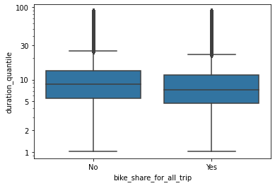

```python
sb.boxplot(data=df_clean,x='bike_share_for_all_trip',y='duration_quantile',color=base_color)
plt.yscale('log')
plt.yticks([1,2,5,10,30,100],[1,2,5,10,30,100]);
```

People without the bike share for all service have longer trips. An analysis between the different characterstics of the users could reveal the reason. I won't dive deep in the analysis of this feature.

### Relationship between gender and age

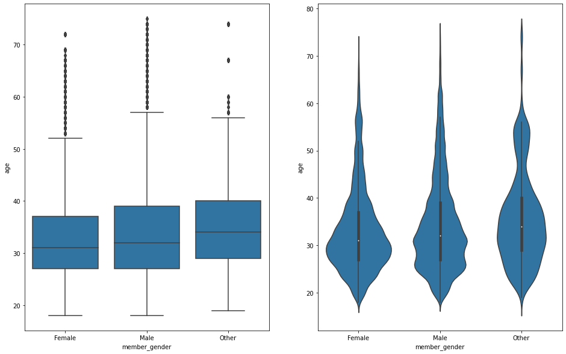

```python
plt.figure(figsize=[16,10])
plt.subplot(1,2,1)
sb.boxplot(data=df_clean,x='member_gender',y='age',color=base_color)
plt.subplot(1,2,2)
sb.violinplot(data=df_clean,x='member_gender',y='age',color=base_color)
```

The male users are older than the female users. The female age distribution is concentrated around 29-30 years, while male distribution is narrower around these values but have more values above 50 years. **This can be the reason why the female users use the bikes for longer time.**

### Relationship between user type and gender

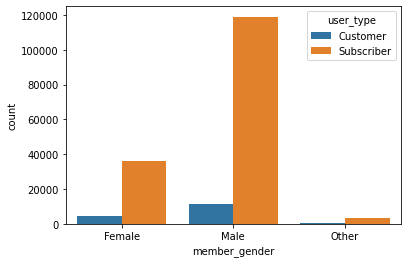

```python
sb.countplot(data=df_clean,x='member_gender',hue='user_type')
```

As expected, since the male are the majority, the male users are the majority as subsribers. A better metric here could be the percentage of each group as customer and subsriber.

### Relation between age and user type

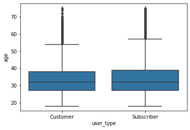

```python
sb.boxplot(data=df_clean,x='user_type',y='age',color=base_color)
```

Customers and subscribers have the same median age and the IQR and range are close, but subscribers have bigger values above 50 (average of the subscribers is slightly higher, but as we still have high age values, I think median is more accurate). This is interesting (the same median age) because this could eliminate the age as the cause that customers trips are longer than the subscribers trips. This will shift the analysis to the date and time of usage in order to determine the difference in the trips duration of customers and subscribers.

### Relation between day of week and user type

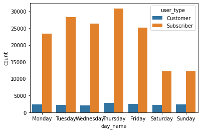

```python
sb.countplot(data=df_clean,x='day_name',hue='user_type')
```

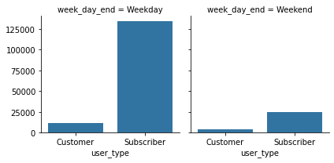

```python
g=sb.FacetGrid(data=df_clean,col='week_day_end')
g.map(sb.countplot,'user_type')
```

There is a clear drop in the number of subscribers during the weekend. This drop also occurs among the customers but it is less significant. This indicates that the main purpose for subscribers is to use the bikes for going to work.

### Relation beween weekdays/end and hour of usage

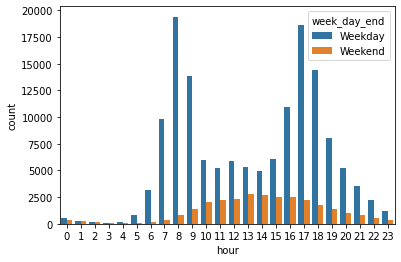

```python
sb.countplot(data=df_clean,x='hour',hue='week_day_end')
```

This graph proves that the usage of the service during the weekdays is going and returning from work as we have two peaks at 8 am and 5pm in the weekdays. The time of usage during the weekend peaks at the noon, which means is not related to trips to work.

### Relationship between hour of day and user type

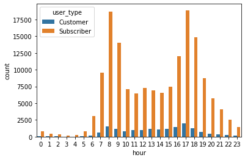

```python
sb.countplot(data=df_clean,x='hour',hue='user_type')
```

The subscribers ride mainly in the hours of start and end of the work, which are supposed to be faster trips, while this drops during the day. This trend could be observed among the customers but not in the same significance. As the trend between customers and subscribers is simliar, I am not sure that we can conclude that subsribers trips are shorter because they bike in order to get to work. Further investigation is needed in multivariate analysis.

### Realtionship between start and end station (Routes)

```python
#prepare the data to see what is the most common routes taken by the users based on start and en station
most_route = df_clean.groupby(['start_station_name','end_station_name']).size()
most_route = most_route.reset_index(name='count')
# I need to see just the routes that was taken more than 200 times during the month
most_route = most_route[most_route['count'] > 200]
most_route = most_route.pivot(index='start_station_name',columns='end_station_name',values='count')
most_route.head(1)
```

| end_station_name start_station_name | 19th Street BART Station | 5th St at Virginia St | Bancroft Way at Telegraph Ave | Grand Ave at Perkins St | Montgomery St BART Station (Market St at 2nd St) | Powell St BART Station (Market St at 4th St) | San Fernando St at 4th St | San Fernando St at 7th St | San Francisco Caltrain Station 2 (Townsend St at 4th St) | San Francisco Ferry Building (Harry Bridges Plaza) | Steuart St at Market St | The Embarcadero at Sansome St |
| --- | --- | --- | --- | --- | --- | --- | --- | --- | --- | --- | --- | --- |
| 19th Street BART Station | NaN | NaN | NaN | 281.0 | NaN | NaN | NaN | NaN | NaN | NaN | NaN | NaN |

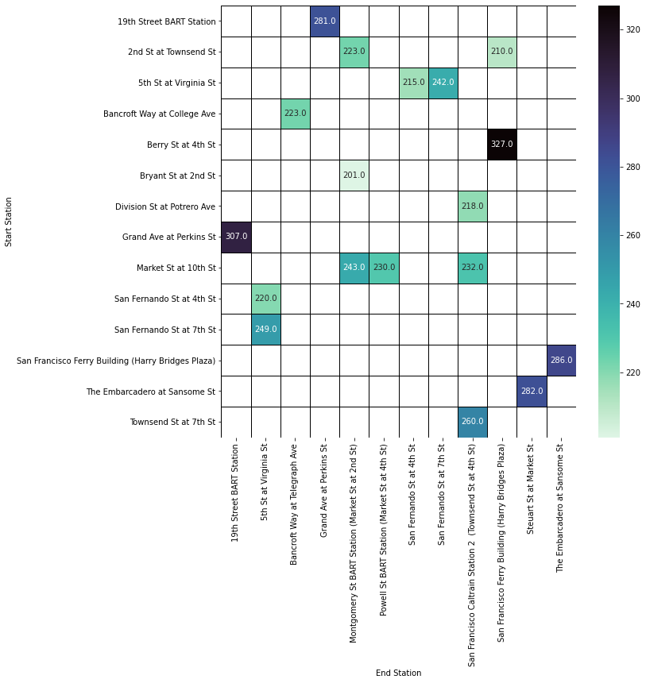

```python
plt.figure(figsize=[10,10])
sb.heatmap(most_route,annot=True,fmt='.1f',linewidths=.5,linecolor='black',cmap="mako_r")
plt.xlabel('End Station')
plt.ylabel('Start Station');
```

This analysis shows that the most taken routes from the start to the end station are from berry st 4th st to San Francisco Ferry Building, from Grand Ave at Perkins to 19th street BART Station, and from San Franscisco Ferry building to The Embbarcdo at Sansome St. A deep analysis could involve more features such as the distance of the most common routes, its relation with the user type and duration. Unfortunately, I will not dive deeper as my focus is concentrated on the duration and time of the trips and the users characteristics.

### Talk about some of the relationships you observed in this part of the investigation. How did the feature(s) of interest vary with other features in the dataset?

> The duration of the trips depends on the characteristics of the users, especially age. The duration of the trips is longer among the young users than among old users. This also can be the reason why the duration of the trips is longer for the female riders since the female users are younger than the males users. In addition, the duration of the trips is affected by the day of the week, as in the weekends the duration is longer than duration in the rest of the week. The subscribers ride for less time than the customers and this could be the result of the purpose of riding of the subscribers -this cannot be result of age as the two groups have a close average age and same median age - since the majority of subsribers use the service to and from the work, **at 8am and 5 pm**, during the weekdays.

### Did you observe any interesting relationships between the other features (not the main feature(s) of interest)?

> It is interesting to see that customers have longer trips in average than the subscribers while the median age is the same, and particularly since we saw that the duration depends on the age.

## Multivariate Exploration

### Relationship between Duration, Age, and User Type

Since the duration depends on the age and the customers duration is higher than the subscribers duration although they have the same median age (the average of the subscribers is a little bit higher), I will try here to visualize the relation between these three variables (user type, duration and age).

```python
def hist2grid(x,y,**kwargs):
    '''Draw a heatmap in the seaborn FacetGrid'''
    palette = kwargs.pop('color')
    x_bin = np.arange(x.min(),x.max()+4,4)
    y_bin = np.arange(y.min(),y.max()+0.2,0.2)
    plt.hist2d(x,y,bins=[x_bin,y_bin],cmap=palette,cmin=0.5)
    plt.yticks(log_trans(np.array([1,3,10,30,100])),
               [1,3,10,30,100]);
```

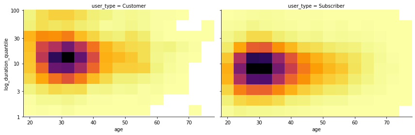

```python
plt.figure(figsize=[16,12])
gi = sb.FacetGrid(data=df_clean,col='user_type',height=4,aspect=1.5)
gi.map(hist2grid,'age','log_duration_quantile',color='inferno_r');
```

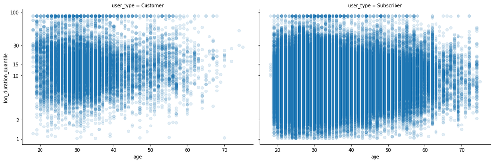

```python
gi = sb.FacetGrid(data=df_clean,col='user_type',palette='viridis_r',height=5,aspect=1.5)
gi.map(sb.regplot,'age','log_duration_quantile',fit_reg=False,scatter_kws={'alpha':1/8})
gi.add_legend()
plt.yticks(log_trans(np.array([1,2,10,15,30,100])),
               [1,2,10,15,30,100]);
```

The heatmap and scatter plot above give us a better idea about why the cutomer trips are longer than that was shown in the boxplot of the bivariate analysis. We can see that the customers are little bit younger, as shown above as most customers are between 25 and 40 while some subscribers are older (above 50 years . Since the relation between age and duration shows that young users tend to have longer trip, the age might play a role in why customers have longer trips as average.

### Duration, Age and Gender

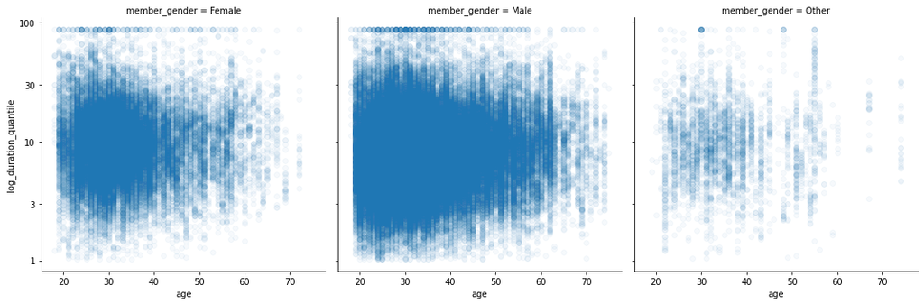

```python
plt.figure(figsize=[16,10])
g=sb.FacetGrid(data=df_clean,col='member_gender',height=5)
g.map(sb.regplot,'age','log_duration_quantile',scatter_kws={'alpha':1/25},fit_reg=False);
plt.yticks(log_trans(np.array([1,3,10,30,100])),
               [1,3,10,30,100]);
```

The scatter above shows the same thing with relation between age and duration of trips. The female users are younger than the male users and thus the duration of the trips taken by the female are longer.

### Day of week, Duration,and User Type

In order to investigate why duration of customers differ than the duration of the subsribers and if others variables have an effect, I will look at the relation with the timing of the trips betweenn the two category.

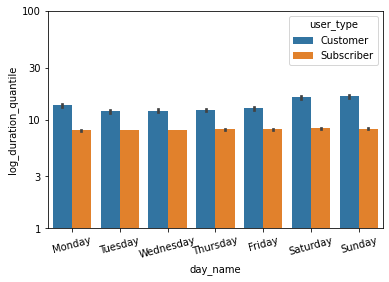

```python
sb.barplot(data=df_clean,x='day_name',y='log_duration_quantile',hue='user_type')
plt.yticks(log_trans(np.array([1,3,10,30,100])),
               [1,3,10,30,100]);
plt.xticks(rotation=15);
```

We can see that the duration of the trips in the weekend increase among customers while the increase of the subscribers duration between weekend and weekday is small. This shows that the day of the week affects the duration of the trips as the customers duration in the weekend are higher which indicates that the purpose of the customers is not just work related and the subscribers used it for the work in the first place. An important idea here is to look at the duration of trips by hour between the customers and subscribers to prove that the difference of duration is caused also (with age) by the timing of usage of the two categories.

### Duration, hour and user type

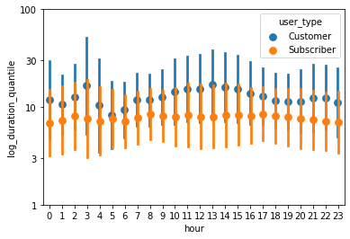

```python
### user, duration, hour
sb.pointplot(data=df_clean,x='hour',y='log_duration_quantile',ci='sd',hue='user_type',linestyles="",dodge=True)
plt.yticks(log_trans(np.array([1,3,10,30,100])),
               [1,3,10,30,100]);
```

### hour, day of week and user type

```python
#creating a dataframe for each group
df_customer = df_clean.query('user_type == "Customer"')
df_sub = df_clean.query('user_type == "Subscriber"')
```

```python
#prepare data to plot in heatmap
def pivotToHeatMap(data,*args):
    d = data.groupby([args[0],args[1]]).size()
    d= d.reset_index(name=args[2])
    d = d.pivot(index=args[0], columns=args[1], values=args[2])
    return d
```

```python
# for each uer type
customer_count = pivotToHeatMap(df_customer,'day_name','hour','count')
sub_count = pivotToHeatMap(df_sub,'day_name','hour','count')
```

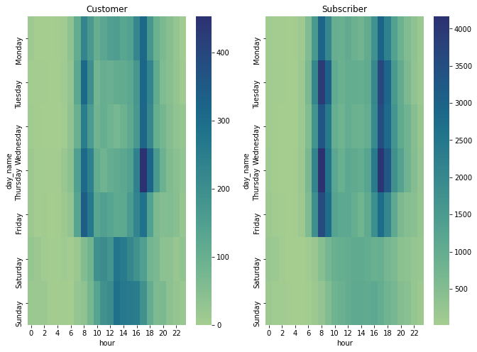

```python
plt.figure(figsize=[11,8])
plt.subplot(1,2,1)
sb.heatmap(customer_count,cmap='crest')
plt.gca().set_title('Customer')
plt.subplot(1,2,2)
sb.heatmap(sub_count,cmap='crest')
plt.gca().set_title('Subscriber')
```

Here, it is clear that the customers use the bike all week for all purpose, while the subscribers use it clearly during just some period of time during the weekdays going and returning from their work, which can justify why the customers took longer trips even though the age of these two groups is close.

### Talk about some of the relationships you observed in this part of the investigation. Were there features that strengthened each other in terms of looking at your feature(s) of interest?

> The analysis of the duration of the trips and age with the gender and type of the users prove that the duration depends on the age. Since the female users are younger than the male users, the duration of the trips taken by the female users are longer.

### Were there any interesting or surprising interactions between features?

> As we saw, the most part of the analysis in this notebook lead to same conclusion, so among the features I analyzed, I didn't find any surprising interactions between them.

> At the end of your report, make sure that you export the notebook as an html file from the `File > Download as... > HTML` menu. Make sure you keep track of where the exported file goes, so you can put it in the same folder as this notebook for project submission. Also, make sure you remove all of the quote-formatted guide notes like this one before you finish your report!

```python
## save df_clean into a csv file for the deck slides notebook
```

```python
df_clean.to_csv('fordGo_clean.csv',index=False)
```